# Lab 2 - Competing Path Models

Structural Equation Modeling ED 216F - Instructor: Karen Nylund-Gibson

Adam Garber

April 09, 2020

# 1 Lab preparation

## 1.1 $\color{purple}{\text{Creating a version-controlled R-Project by downloading repository from Github}}$

Download ropository here: $\color{blue}{\text{https://github.com/garberadamc/SEM-Lab2}}$

On the Github repository webpage:

1. `fork` your own `branch` of the lab repository
2. copy the repository web URL address from the `clone or download` menu

Within R-Studio:

3. click “NEW PROJECT” (upper right corner of window)
4. choose option `Version Control`
5. choose option `Git`
6. paste the repository web URL path coppied from the `clone or download` menu on Github page
7. choose location of the R-Project ($\color{red}{\text{too many nested folders will result in filepath error}}$)

Example of competing path models study from [$\color{blue}{\text{Nishina, Juvonen, Witkow (2005)}}$](https://www.tandfonline.com/doi/pdf/10.1207/s15374424jccp3401_4)

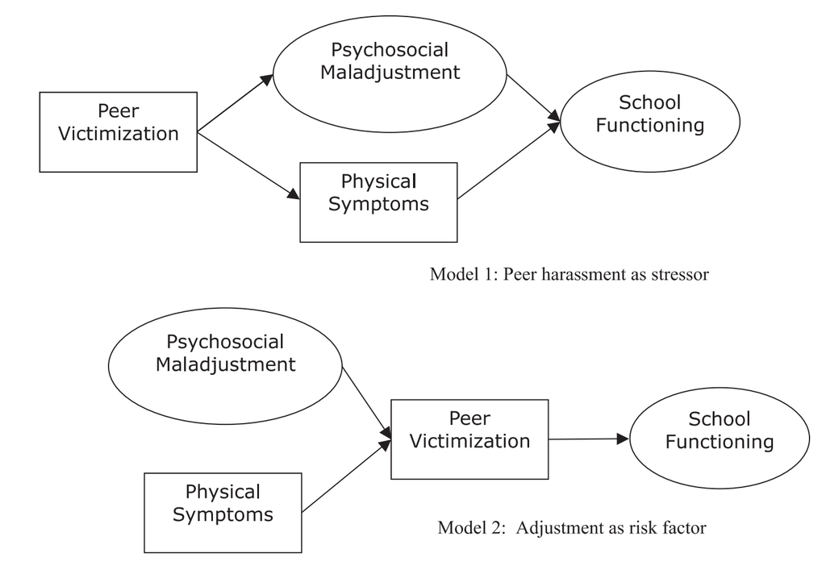

*figure*. Picture adapted from Nishina, Juvonen, Witkow (2005)

## 1.2 Data source:

This lab exercise utilizes the *California Test Score Data Set 1998-1999* from the California Department of Education (Stock, James, and Watson, 2003) [$\color{blue}{\text{See documentation here}}$](https://vincentarelbundock.github.io/Rdatasets/doc/Ecdat/Caschool.html)

This dataset is available via the R-package {`Ecdat`} and can be directly loaded into the R environment.

**Note:** All models specified in the following exercise are for demonstation only and are **not** theoretically justified or valid. ______________________________________________

## 1.3 List of over 1000 datasets available in R packages

This list was compiled by Vincent Arel-Bundock and can be found here:

[$\color{blue}{\text{https://vincentarelbundock.github.io/Rdatasets/datasets.html}}$](https://vincentarelbundock.github.io/Rdatasets/datasets.html)

Install the “rhdf5” package to read gh5 files

```r
if (!requireNamespace("BiocManager", quietly = TRUE))
    install.packages("BiocManager")
 BiocManager::install("rhdf5")
```

Load packages

```r
library(MplusAutomation)
library(haven)
library(rhdf5)
library(tidyverse)
library(here)
library(corrplot)
library(kableExtra)
library(reshape2)
library(janitor)
library(ggridges)
library(DiagrammeR)
library(semPlot)
library(sjPlot)
library(Ecdat)
library(gt)
library(gtsummary)
```

# 2 Begin lab 2 exercise

Read the dataframe into your R-environment from package {`Ecdat`}

```r
data(Caschool)

ca_schools <- as.data.frame(Caschool)
```

Look at the data with `glimpse`

```r
glimpse(ca_schools)
```

[output not shown]

Subset variables to use in path model analyses with `select`

```r
path_vars <- ca_schools %>%
  select(str, expnstu, compstu, elpct, mealpct,
         readscr, mathscr, testscr)
```

# 3 Explore the data

K through 8th grade schools in California ($N = 420$)

Take a look at focal variables, make a `tribble` table

```r
var_table <- tribble(
   ~"Name",    ~"Labels",
 #-----------|----------------------------------------------|,
  "str"       , "student teacher ratio"                      ,
  "expnstu"   , "expenditure per student"                    ,
  "compstu"   , "computer per student"                       ,
  "elpct"     , "percent of English learners"                ,
 "mealpct"    , "percent qualifying for reduced-price lunch" ,
  "readscr"   , "average reading score"                      ,
  "mathscr"   , "average math score"                         ,
  "testscr"   , "average test score (read.scr+math.scr)/2"   )

var_table %>%
  kable(booktabs = T, linesep = "") %>%
  kable_styling(latex_options = c("striped"),
                full_width = F,
                position = "left")
```

| Name | Labels |
| --- | --- |
| str | student teacher ratio |
| expnstu | expenditure per student |
| compstu | computer per student |
| elpct | percent of English learners |
| mealpct | percent qualifying for reduced-price lunch |
| readscr | average reading score |
| mathscr | average math score |
| testscr | average test score (read.scr+math.scr)/2 |

check some basic descriptives with the {`gtsummary`} package

```r
table1 <- tbl_summary(path_vars,
                      statistic = list(all_continuous() ~ "{mean} ({sd})"),
                      missing = "no" ) %>%
  bold_labels()

table1
```

| **Characteristic** | **N = 420**<sup>1</sup> |
| --- | --- |
| str | 19.64 (1.89) |
| expnstu | 5312 (634) |
| compstu | 0.14 (0.06) |
| elpct | 16 (18) |
| mealpct | 45 (27) |
| readscr | 655 (20) |
| mathscr | 653 (19) |
| testscr | 654 (19) |

<sup>*1*</sup> Statistics presented: mean (SD)

look at shape of variable distributions

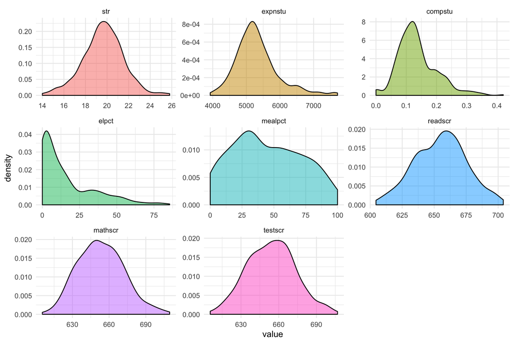

```r
melt(path_vars) %>%
  ggplot(., aes(x=value, label=variable)) +
  geom_density(aes(fill = variable),
               alpha = .5, show.legend = FALSE) +
  facet_wrap(~variable, scales = "free")  +
  theme_minimal()
```

look at correlation matrix with {`corrplot`}

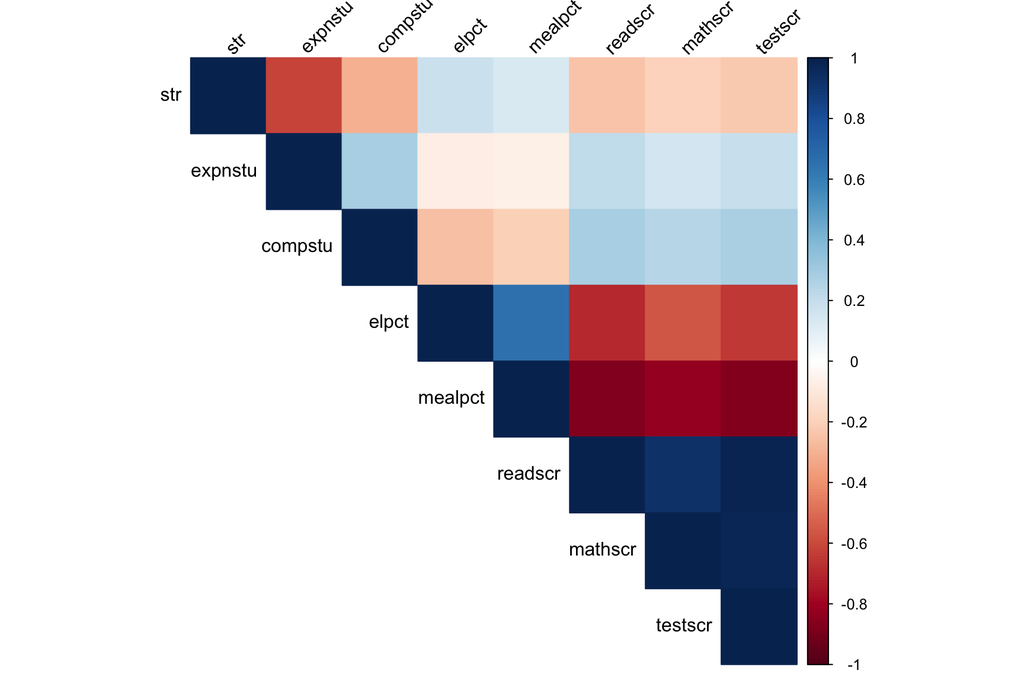

```r
p_cor <- cor(path_vars, use = "pairwise.complete.obs")

corrplot(p_cor,
         method = "color",
         type = "upper",
         tl.col="black",
         tl.srt=45)
```

# 4 Specifying path models using {`MplusAutomation`}

recall what the unrestricted variance-covariance matrix **looks** like

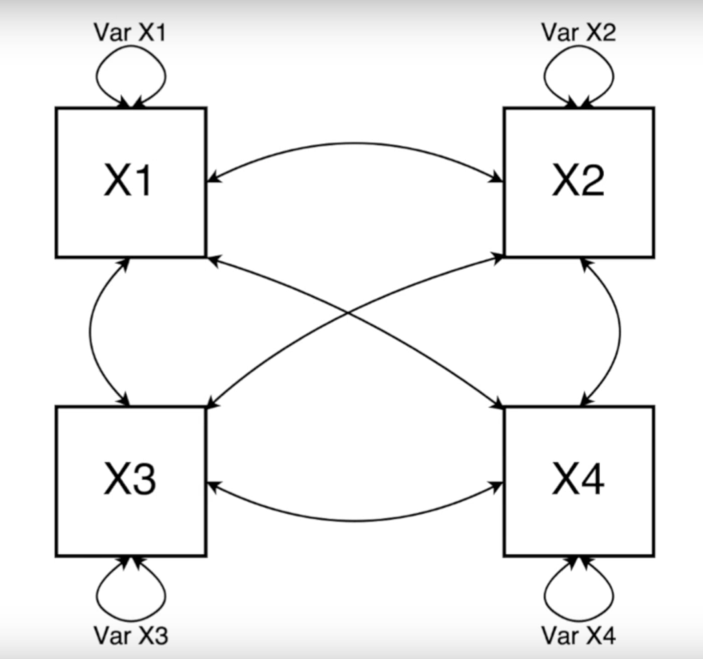

*figure*. Unrestricted variance covariance matrix picture from {`openMX`} video tutorial.

## 4.1 Estimate model 1

Indirect path model:

1. covariate: ratio of computers to students (`compstu`)
2. mediator: percent qualifying for reduced-price lunch (`mealpct`)
3. outcome: average math score (`mathscr`)

Path diagram model 1

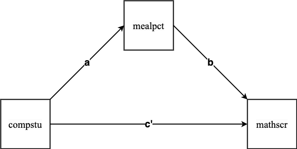

```r
m1_path  <- mplusObject(
  TITLE = "m1 model indirect - Lab 1",
  VARIABLE =
   "usevar =
    compstu         ! covariate
    mealpct         ! mediator
    mathscr;        ! outcome",

  ANALYSIS =
    "estimator = MLR" ,

  MODEL =
   "mathscr on compstu;         ! direct path (c')
    mathscr on mealpct;         ! b path
    mealpct on compstu;         ! a path

    Model indirect:
    mathscr ind compstu;" ,

  OUTPUT = "sampstat standardized modindices (ALL)",

  usevariables = colnames(path_vars),
  rdata = path_vars)

m1_path_fit <- mplusModeler(m1_path,
                     dataout=here("mplus_files", "Lab2.dat"),
                    modelout=here("mplus_files", "m1_path_Lab2.inp"),
                    check=TRUE, run = TRUE, hashfilename = FALSE)
```

View path diagram for model 1 with standardized estimates (using Diagrammer in Mplus)

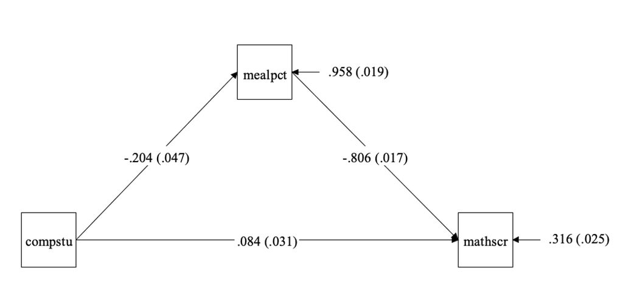

## 4.2 Estimate model 2

Indirect path model:

Path diagram model 2

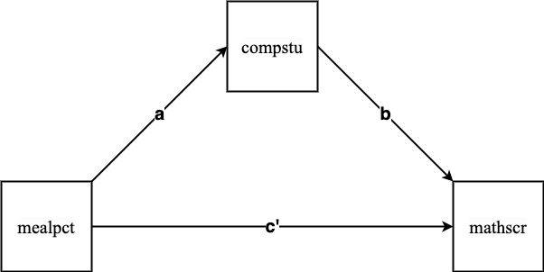

```r
m2_path  <- mplusObject(
  TITLE = "m1 model indirect - Lab 1",
  VARIABLE =
   "usevar =
    mealpct           ! covariate
    compstu           ! mediator
    mathscr;          ! outcome",

  ANALYSIS =
    "estimator = MLR" ,

  MODEL =
   "mathscr on compstu;         ! direct path (c')
    mathscr on mealpct;         ! b path
    mealpct on compstu;         ! a path

    Model indirect:
    mathscr ind compstu;" ,

  OUTPUT = "sampstat standardized modindices (ALL)",

  usevariables = colnames(path_vars),
  rdata = path_vars)

m2_path_fit <- mplusModeler(m2_path,
                     dataout=here("mplus_files", "Lab2.dat"),
                    modelout=here("mplus_files", "m2_path_Lab2.inp"),
                    check=TRUE, run = TRUE, hashfilename = FALSE)
```

[figure not shown]

## 4.3 Estimate model 3

Path model with interaction (moderation):

1. covariate-moderator: percent qualifying for reduced-price lunch (`mealpct`)
2. covariate-moderator: ratio of computers to students (`compstu`)
3. outcome: average math score (`mathscr`)

Path diagram model 3

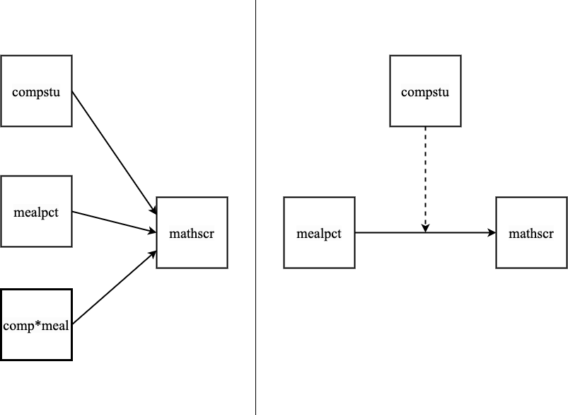

```r
m3_path  <- mplusObject(
  TITLE = "m1 model indirect - Lab 1",
  VARIABLE =
   "usevar =
    compstu           ! covariate-moderator
    mealpct           ! covariate-moderator
    mathscr           ! outcome
    int_ab;           ! interaction term ",

  DEFINE =
    "int_ab = compstu*mealpct;  ! create interaction term" ,

  ANALYSIS =
    "estimator = MLR" ,

  MODEL =
   "mathscr on compstu mealpct int_ab; ",

  OUTPUT = "sampstat standardized modindices (ALL)",

  usevariables = colnames(path_vars),
  rdata = path_vars)

m3_path_fit <- mplusModeler(m3_path,
                     dataout=here("mplus_files", "Lab2.dat"),
                    modelout=here("mplus_files", "m3_path_Lab2.inp"),
                    check=TRUE, run = TRUE, hashfilename = FALSE)
```

View path diagram for model 3 with standardized estimates (using the Diagrammer in Mplus)

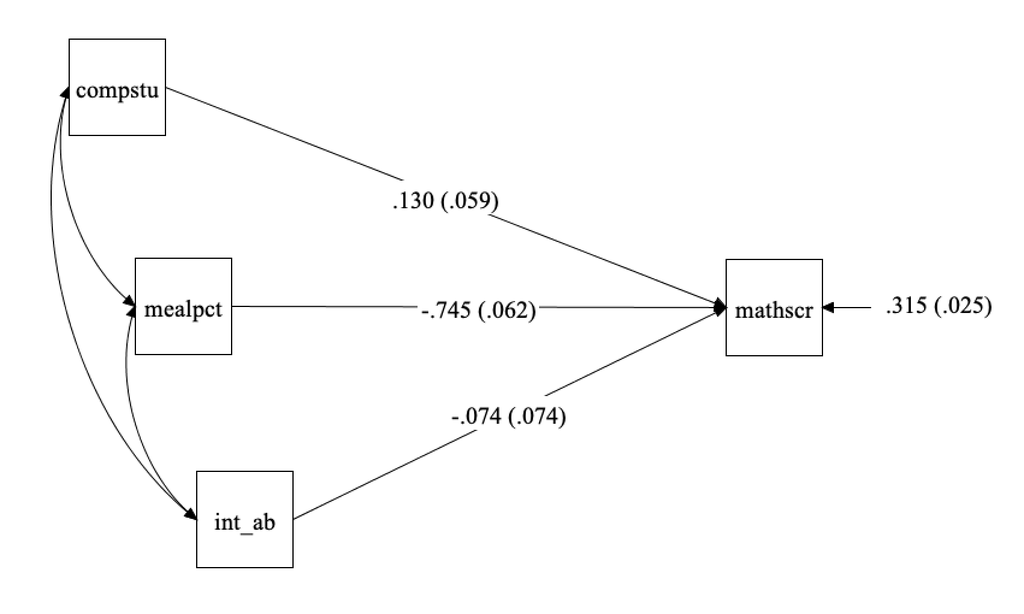

## 4.4 Estimate model 4

```r
m4_path  <- mplusObject(
  TITLE = "m4 model indirect - Lab 1",
  VARIABLE =
   "usevar =
    str               ! covariate
    elpct             ! mediator
    mealpct           ! mediator
    mathscr           ! outcome",

  DEFINE =
    "int_ab = compstu*mealpct;  ! create interaction term" ,

  ANALYSIS =
    "estimator = MLR" ,

  MODEL =
   "mathscr on str;             ! direct path (c')
    mathscr on elpct mealpct;   ! b paths
    elpct mealpct on str;       ! a paths

    Model indirect:
    mathscr ind str;" ,

  OUTPUT = "sampstat standardized modindices (ALL)",

  usevariables = colnames(path_vars),
  rdata = path_vars)

m4_path_fit <- mplusModeler(m4_path,
                     dataout=here("mplus_files", "Lab2.dat"),
                    modelout=here("mplus_files", "m4_path_Lab2.inp"),
                    check=TRUE, run = TRUE, hashfilename = FALSE)
```

View path diagram for model 4 with standardized estimates (using the Diagrammer in Mplus)

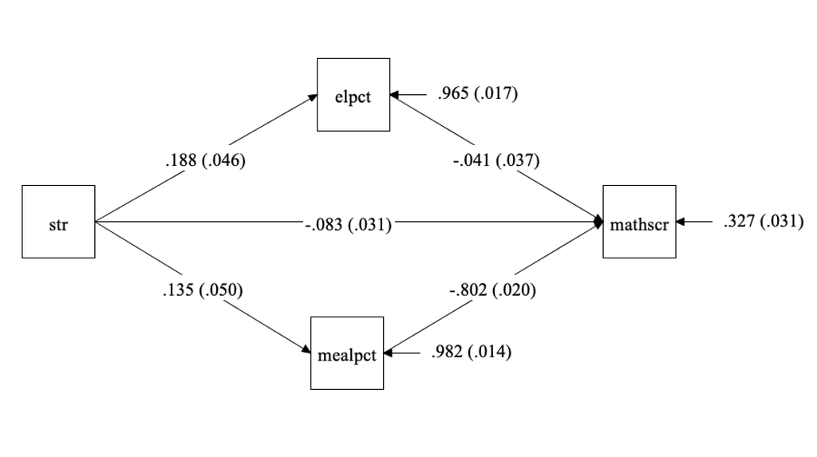

## 4.5 Estimate model 5

add modification statement - correlate mediators `mealpct with elpct`

```r
m5_path  <- mplusObject(
  TITLE = "m5 model indirect - Lab 1",
  VARIABLE =
   "usevar =
    str               ! covariate
    elpct             ! mediator
    mealpct           ! mediator
    mathscr           ! outcome",

  DEFINE =
    "int_ab = compstu*mealpct;  ! create interaction term" ,

  ANALYSIS =
    "estimator = MLR" ,

  MODEL =
   "mathscr on str;             ! direct path (c')
    mathscr on elpct mealpct;   ! b paths
    elpct mealpct on str;       ! a paths

    mealpct with elpct          ! modification statement

    Model indirect:
    mathscr ind str; " ,

  OUTPUT = "sampstat standardized modindices (ALL)",

  usevariables = colnames(path_vars),
  rdata = path_vars)

m5_path_fit <- mplusModeler(m5_path,
                     dataout=here("mplus_files", "Lab2.dat"),
                    modelout=here("mplus_files", "m5_path_Lab2.inp"),
                    check=TRUE, run = TRUE, hashfilename = FALSE)
```

View path diagram for model 5 with standardized estimates (using the Diagrammer in Mplus)

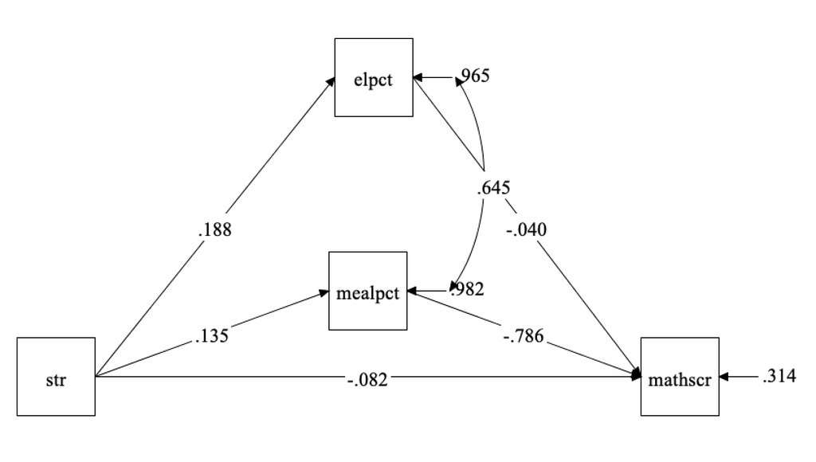

# 5 Compare model fit

Read into R summary of all models

```r
all_models <- readModels(here("mplus_files"))
```

Extract fit indice data from output files

```r
summary_fit <- LatexSummaryTable(all_models,
                 keepCols=c("Filename", "Parameters","ChiSqM_Value", "CFI","TLI",
                            "SRMR", "RMSEA_Estimate", "RMSEA_90CI_LB", "RMSEA_90CI_UB"),
                 sortBy = "Filename")
```

Create a customizable table using the {`gt`} package

```r
model_table <- summary_fit %>%
  gt() %>%
  tab_header(
    title = "Fit Indices",  # Add a title
    subtitle = ""           # And a subtitle
  ) %>%
  tab_options(
    table.width = pct(80)
  ) %>%
  tab_footnote(
    footnote = "California Test Score Data Set 1998-1999",
    location = cells_title()
  ) %>%
  cols_label(
    Filename = "Model",
    Parameters =  "Par",
    ChiSqM_Value = "ChiSq",
    RMSEA_Estimate = "RMSEA",
    RMSEA_90CI_LB = "Lower CI",
    RMSEA_90CI_UB = "Upper CI")

model_table
```

[output not shown]

# 6 End of Lab 2

# 7 References

Hallquist, M. N., & Wiley, J. F. (2018). MplusAutomation: An R Package for Facilitating Large-Scale Latent Variable Analyses in Mplus. Structural equation modeling: a multidisciplinary journal, 25(4), 621-638.

Horst, A. (2020). Course & Workshop Materials. GitHub Repositories, https://https://allisonhorst.github.io/

Ingels, S. J., Pratt, D. J., Herget, D. R., Burns, L. J., Dever, J. A., Ottem, R., … & Leinwand, S. (2011). High School Longitudinal Study of 2009 (HSLS: 09): Base-Year Data File Documentation. NCES 2011-328. National Center for Education Statistics.

Muthén, L.K. and Muthén, B.O. (1998-2017). Mplus User’s Guide. Eighth Edition. Los Angeles, CA: Muthén & Muthén

R Core Team (2017). R: A language and environment for statistical computing. R Foundation for Statistical Computing, Vienna, Austria. URL http://www.R-project.org/

Wickham et al., (2019). Welcome to the tidyverse. Journal of Open Source Software, 4(43), 1686, https://doi.org/10.21105/joss.01686